# Ideas cascading into keystrokes – Modelling writing hesitations as Bayesian mixture process

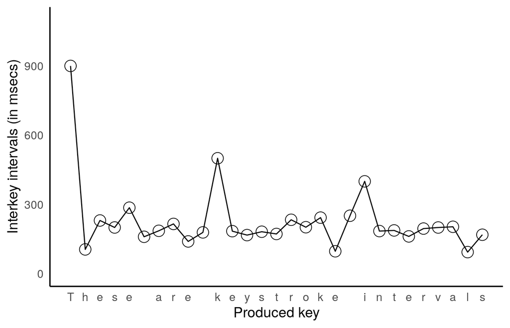

- Understanding factors that influence interkey intervals requires a theory of how keystrokes are sequenced.
- Which processes are required and how are they coordinated?

## How do we produce texts?

## How do we produce texts?

[figure not shown]

## Planning text

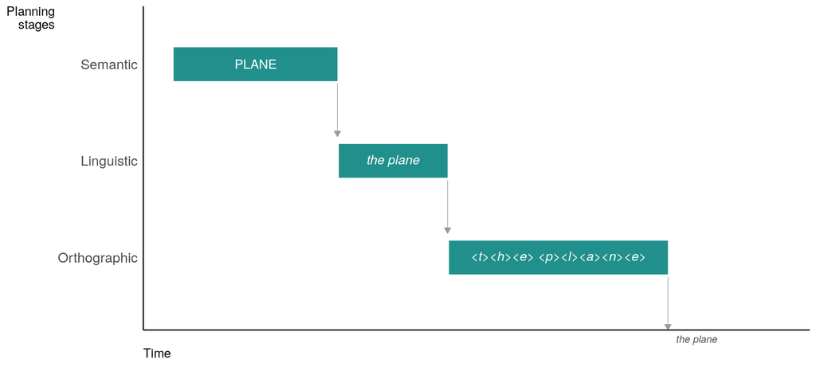

## Classic (serial) view of writing

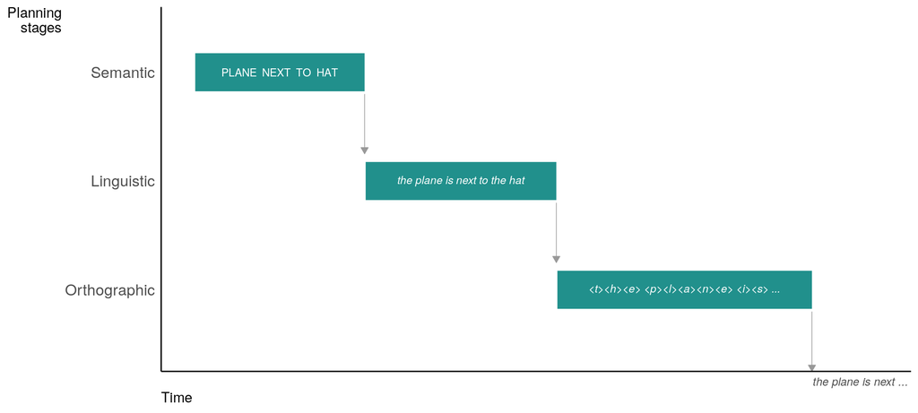

## Classic (serial) view of writing

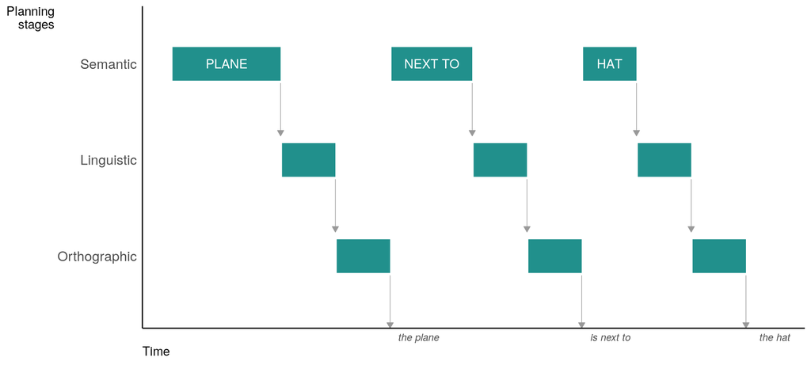

## Parallel view of writing (Olive 2014)

[figure not shown]

## Parallel view of writing (Olive 2014)

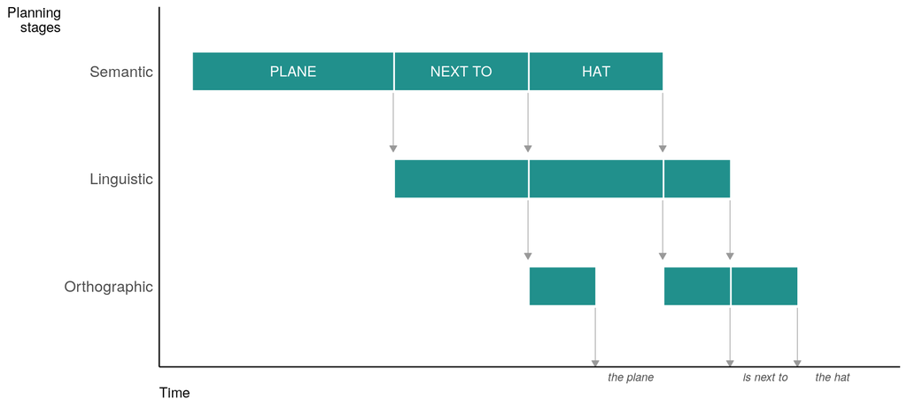

## Parallel view of writing (Olive 2014)

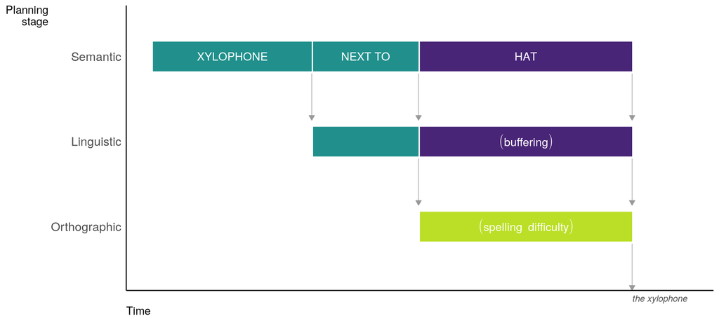

## Serial view

- Interkey intervals are longer at larger linguistic edges following relatively fluent production bursts (Chenoweth and Hayes 2001; Hayes 2012; Kaufer, Hayes, and Flower 1986).
- Mean pause duration before a writer starts a sentence is typically longer than before a mid-sentence word and these are, in turn, longer than between mid-word key presses (e.g. Conijn, Roeser, and van Zaanen 2019).
- Planning message and syntax for the next sentence adds to the time required to prepare the upcoming word, and the motor planning required to produce the first keystroke (Baaijen, Galbraith, and De Glopper 2012; Roeser, Torrance, and Baguley 2019).

## Two distinct data-generating processes leading to a mixture of two distributions of interkey intervals (Roeser et al. 2021).

- Minimum interkey intervals for executing motor movements; 100-150 msecs (Conijn, Roeser, and van Zaanen 2019; Van Waes et al. 2021).
- If upstream processes provide output more slowly, then interkey intervals are determined by time taken to complete upstream processes and not on finger movement.
- Neither process (or distribution of keystrokes) can be explained on the basis of the keystroke location in the text.

## How can we represent these models statistcally?

## Serial view: single-process model

\[ \text{iki}_i \sim\text{ } \text{log}\mathcal{N}(\beta, \sigma_{e}^2) \]

## Serial view: single-process model

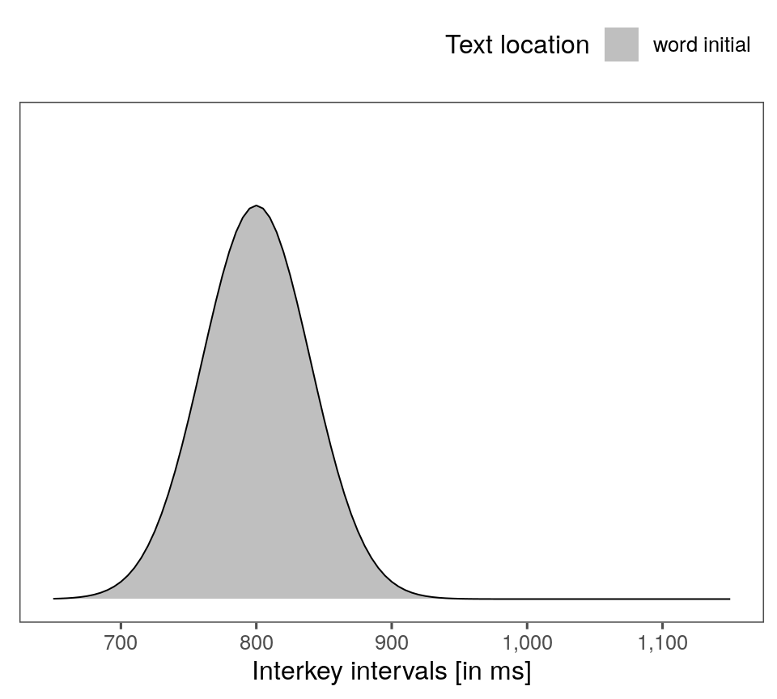

\[ \text{iki}_i \sim\text{ } \text{log}\mathcal{N}(\beta, \sigma_{e}^2) \]

## Serial view: single-process model

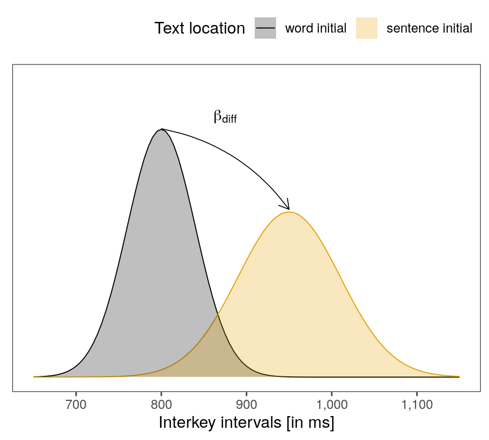

\[ \text{iki}_i \sim\text{ } \text{log}\mathcal{N}(\beta_\text{textlocation[i]}, \sigma_{e_\text{textlocation[i]}}^2) \]

## Parallel view: mixture of two processes

\[ \text{iki}_{i} \sim\text{ } \theta \times \text{log}\mathcal{N}(\beta + \delta, \sigma_{e'}^2) + \\ (1 - \theta) \times \text{log}\mathcal{N}(\beta, \sigma_{e}^2) \]

## Parallel view: mixture of two processes

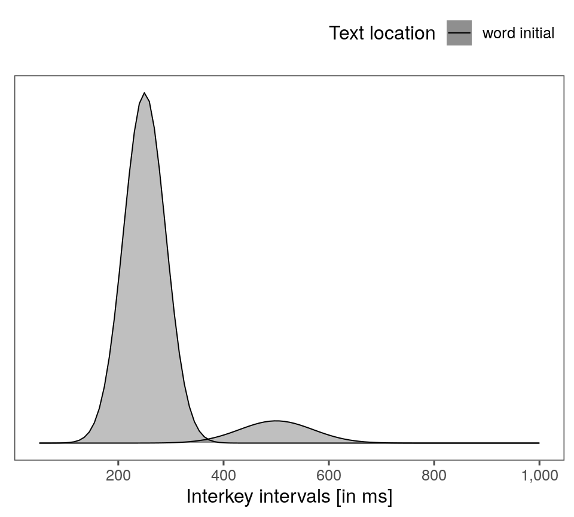

\[ \text{iki}_{i} \sim\text{ } \theta \times \text{log}\mathcal{N}(\beta + \delta, \sigma_{e'}^2) + \\ (1 - \theta) \times \text{log}\mathcal{N}(\beta, \sigma_{e}^2) \]

## Parallel view: mixture of two processes

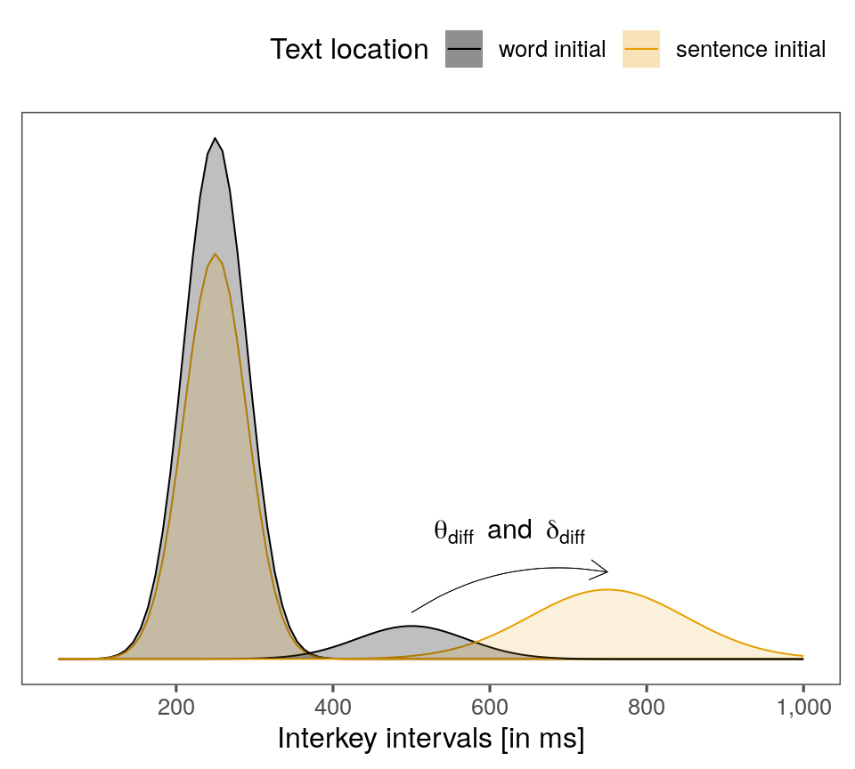

\[ \text{iki}_{i} \sim\text{ } \theta_\text{location[i]} \times \text{log}\mathcal{N}(\beta + \delta_\text{location[i]}, \sigma_{e'_\text{location[i]}}^2) + \\ (1 - \theta_\text{location[i]}) \times \text{log}\mathcal{N}(\beta, \sigma_{e_\text{location[i]}}^2) \]

## How can we evaluate these models?

## Data sets

| Dataset | Source | Keylogger | Task | N | Age | Sample | Country | Language |
| --- | --- | --- | --- | --- | --- | --- | --- | --- |
| C2L1 | Rønneberg et al. (2022) | EyeWrite | Argumentative | 126 | 12 | 6th graders | Norway | Norwegian |
| CATO | Torrance et al. (2016) | EyeWrite | Expository | 52 | 17 | Secondary school students (dyslexic, non dyslexic) | Norway | Norwegian |
| GE2 | Ofstad Oxborough and Torrance (2011) | EyeWrite | Argumentative | 45 | 19 | Undergraduate students | UK | English |
| LIFT | Vandermeulen et al. (2020) | InputLog | Synthesis | 658 | 17 | Secondary school students | The Netherlands | Dutch |
| PLanTra | Rossetti and Van Waes (2022) | InputLog | Text simplification | 47 | 23 | Master students | Belgium | English (L2) |
| SPL2 | Torrance, Roeser, and Chukharev (n.d.) | CyWrite | Argumentative | 39 | 21 | Undergraduate students | USA | English |

## Text location classifications

[output not shown]

<sup>a</sup> Note: Key intervals that terminated in a revision were removed.

## Model overview

| Models | Description |
| --- | --- |
| **Serial** |  |
| M1 | Single distribution Gaussian |
| M2 | Single distribution log-Gaussian |
| M3 | Single distribution log-Gaussian with different variance components per text location |
| **Parallel** |  |
| M4 | Two-distributions mixture of log-Gaussians. |

## Implentation

- Bayesian inference (e.g. Lambert 2018)
- Random effects for participants (see Roeser et al. 2021) with code based on Vasishth et al. (2017)
- Stan (Carpenter et al. 2016) using `rstan` (Stan Development Team 2018) to interface with \(R\)
- Leave-one-out cross-validation estimated as the sum of the expected log predictive density \(\widehat{elpd}\) and compared by the difference between models \(\Delta\widehat{elpd}\) (Vehtari, Gelman, and Gabry 2015, 2017)
- Difference between models was summarised as \(\mid\frac{\Delta\widehat{elpd}}{\text{SE}}\mid\), the *z*-score of the difference between models (Sivula et al. 2020).

## Which model showed better performance?

## Model comparisons

Vales are the absolute ratio of the difference in predictive performance measured as \(\widehat{elpd}\) and its standard error \(\mid\frac{\Delta\widehat{elpd}}{\text{SE}}\mid\) which corresponds to the \(z\)-score of the difference between models (Sivula et al. 2020).

[output not shown]

## Model comparisons

Vales are the absolute ratio of the difference in predictive performance measured as \(\widehat{elpd}\) and its standard error \(\mid\frac{\Delta\widehat{elpd}}{\text{SE}}\mid\) which corresponds to the \(z\)-score of the difference between models (Sivula et al. 2020).

| Data set | Mixture process (M3 vs M4) | Single process (unequal var.; M2 vs M3) | Single process (M1 vs M2) |
| --- | --- | --- | --- |
| C2L1 | 23 | 13 | 47 |
| CATO | 24 | 18 | 43 |
| GE2 | 27 | 26 | 63 |
| LIFT | 40 | 21 | 46 |
| PLanTra | 26 | 17 | 64 |
| SPL2 | 18 | 25 | 69 |

## Model fit to data

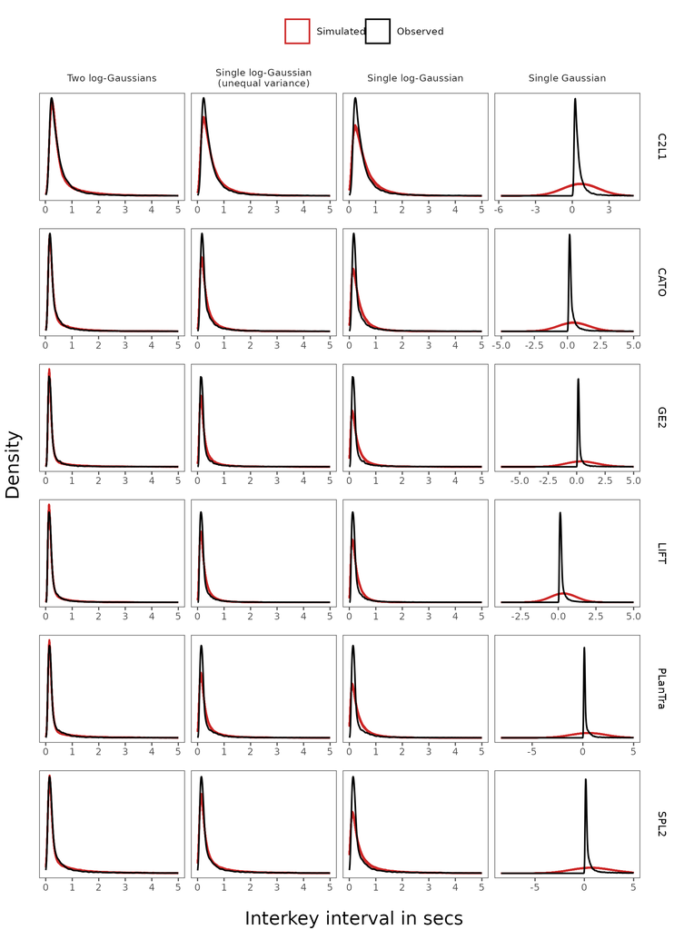

## How do text locations affect the mixture process?

## Mixture distributions

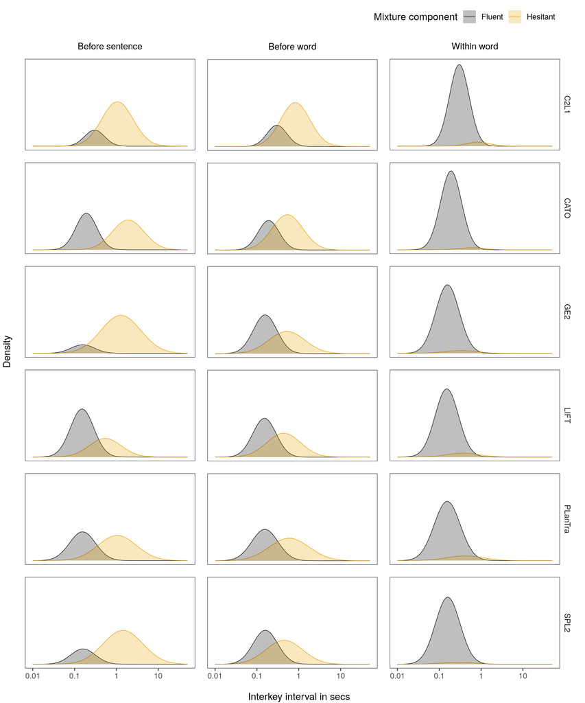

## Location estimates by model parameter

[figure not shown]

## Location estimates by model parameter

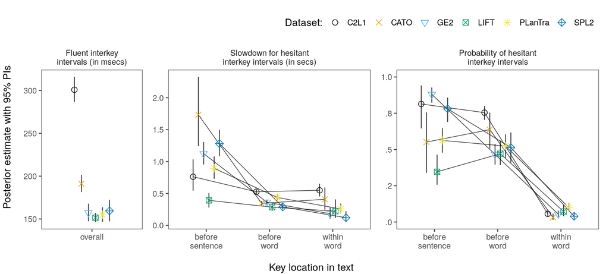

## Location estimates by model parameter

Values indicate BFs in support of the alternative hypothesis over the null hypothesis.

| Dataset | Hesitation slowdown before sentence vs word | Hesitation slowdown before vs within word | Hesitation probability before sentence vs word | Hesitation probability before vs within word |
| --- | --- | --- | --- | --- |
| C2L1 | 1.11 | 0.07 | 0.68 | > 100 |
| CATO | > 100 | 0.2 | 0.67 | > 100 |
| GE2 | > 100 | 26.78 | > 100 | > 100 |
| LIFT | 0.5 | 0.41 | 1.61 | > 100 |
| PLanTra | > 100 | 55.53 | 0.28 | > 100 |
| SPL2 | > 100 | 9.07 | > 100 | > 100 |

## Planning text unfolds in parallel to production!

## Planning text unfolds in parallel to production!

- Writers do not necessarily pause but plan utterances in parallel to writing.
- Evidenced by
  - stronger predictive performance of mixture models (Roeser et al. 2021).
  - pauses are generally equally likely before before sentences compare to before words (but often longer).
- Largely consistent for populations with different levels of writing experience, languages (e.g. young / L2 writers, students), composition tasks.
- First robust evidence that written composition is largely a parallel process.

## “Maybe mixture models just always fit bettter?”

## Simulation

- Simulate data from a single log-normal distribution
- Simulate data from a mixture of to log-normal distribution
- Data simulated with mixture process:
  - Advantage for mixture model over single process model: \(\Delta\widehat{elpd} =\) -191.3 (16.5)
- Data simulated with single process:
  - Negligible difference between models: \(\Delta\widehat{elpd} =\) -0.5 (0.7)

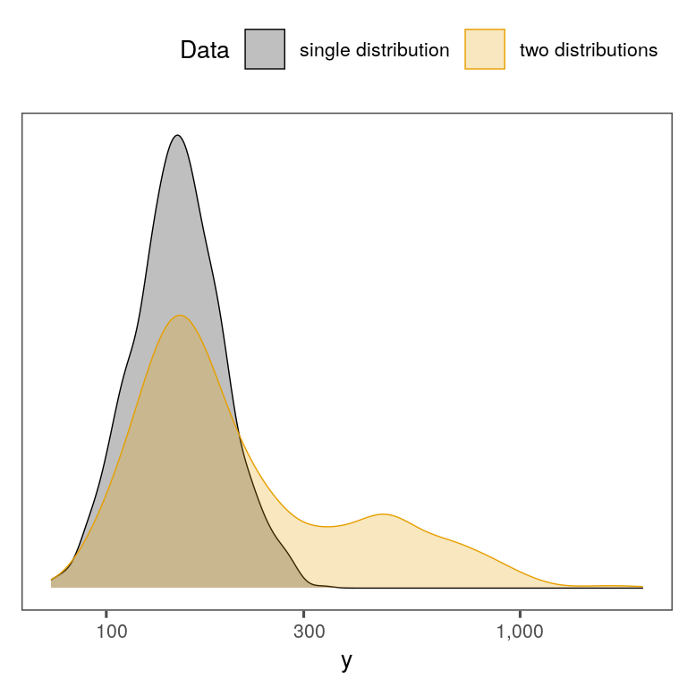

## Thank you!

We are grateful for all authors who made their available (to us), in particular Nina Vandermeulen, Alessandra Rossetti, and colleagues. This work was supported by

- National Science Foundation under Grant No. 2016868: “ProWrite: Biometric feedback for improving college students’ writing processes.” (Iowa State University)
- UKRI ESRC under Grant No. ES/W011832/1: “Can you use it in a sentence?: Establishing how word-production difficulties shape text formation.” (Nottingham Trent University)

Data and analysis scripts written in R and Stan can be found on OSF https://osf.io/z65dw/ (Roeser et al. 2024).

For a tutorial on Bayesian mixture-model analysis in the context of keystroke data see https://rpubs.com/jensroes/mixture-models-tutorial.

## References

Baaijen, Veerle M., David Galbraith, and Kees De Glopper. 2012. “Keystroke Analysis: Reflections on Procedures and Measures.” *Written Communication* 29 (3): 246–77.

Carpenter, Bob, Andrew Gelman, Matt Hoffman, Daniel Lee, Ben Goodrich, Michael Betancourt, Michael A. Brubaker, Jiqiang Guo, Peter Li, and Allen Riddell. 2016. “Stan: A Probabilistic Programming Language.” *Journal of Statistical Software* 20.

Chenoweth, N. Ann, and John R. Hayes. 2001. “Fluency in Writing: Generating Text in L1 and L2.” *Written Communication* 18 (1): 80–98.

Conijn, Rianne, Jens Roeser, and Menno van Zaanen. 2019. “Understanding the Keystroke Log: The Effect of Writing Task on Keystroke Features.” *Reading and Writing* 32 (9): 2353–74.

Hayes, John R. 2012. “Evidence from Language Bursts, Revision, and Transcription for Translation and Its Relation to Other Writing Processes.” In *Translation of Thought to Written Text While Composing: Advancing Theory, Knowledge, Methods, and Applications*, edited by M. Fayol, D. Alamargot, and V. Berninger, 15–25. Psychology Press.

Kaufer, David S., John R. Hayes, and Linda S. Flower. 1986. “Composing Written Sentences.” *Research in the Teaching of English*, 121–40.

Lambert, Ben. 2018. *A Student’s Guide to Bayesian Statistics*. Sage.

Medimorec, Srdan, and Evan F. Risko. 2017. “Pauses in Written Composition: On the Importance of Where Writers Pause.” *Reading and Writing* 30: 1267–85.

Nottbusch, Guido. 2010. “Grammatical Planning, Execution, and Control in Written Sentence Production.” *Reading and Writing* 23 (7): 777–801.

Ofstad Oxborough, Gunn Helen, and Mark Torrance. 2011. “Multilevel Analysis of Latency in Writing.” In *21st Annual Meeting of the Society for Text and Discourse*. http://textanddiscourse2011.conference.univ-poitiers.fr/PROG_DEFIN.pdf.

Olive, Thierry. 2014. “Toward a Parallel and Cascading Model of the Writing System: A Review of Research on Writing Processes Coordination.” *Journal of Writing Research* 6 (2): 173–94.

Roeser, Jens, Rianne Conijn, Evgeny Chukharev, Gunn Helen Ofstad, and Mark Torrance. 2024. “Typing in Tandem: Finite Mixture Models Reveal Fundamental Parallelism in Multi-Sentence Text Composition.” https://osf.io/z65dw/. https://doi.org/10.17605/OSF.IO/Z65DW.

Roeser, Jens, Sven De Maeyer, Mariëlle Leijten, and Luuk Van Waes. 2021. “Modelling Typing Disfluencies as Finite Mixture Process.” *Reading and Writing*, 1–26. https://doi.org/10.1007/s11145-021-10203-z.

Roeser, Jens, Mark Torrance, and Thom Baguley. 2019. “Advance Planning in Written and Spoken Sentence Production.” *Journal of Experimental Psychology: Learning, Memory, and Cognition* 45 (11): 1983–2009. https://doi.org/10.1037/xlm0000685.

Rønneberg, Vibeke, Mark Torrance, Per Henning Uppstad, and Christer Johansson. 2022. “The Process-Disruption Hypothesis: How Spelling and Typing Skill Affects Written Composition Process and Product.” *Psychological Research* 86 (7): 2239–55.

Rossetti, Alessandra, and Luuk Van Waes. 2022. “Text Simplification in Second Language: Process and Product Data.” Zenodo. https://doi.org/10.5281/zenodo.6720290.

Sivula, Tuomas, Måns Magnusson, Asael Alonzo Matamoros, and Aki Vehtari. 2020. “Uncertainty in Bayesian Leave-One-Out Cross-Validation Based Model Comparison.” *arXiv Preprint arXiv:2008.10296*.

Stan Development Team. 2018. “ RStan: The R Interface to Stan.” https://mc-stan.org/.

Torrance, Mark, Jens Roeser, and Evgeny Chukharev. n.d. “Lookback Supports Cascaded, Just-in-Time Processing in Second Language Written Composition.”

Torrance, Mark, Vibeke Rønneberg, Christer Johansson, and Per Henning Uppstad. 2016. “Adolescent Weak Decoders Writing in a Shallow Orthography: Process and Product.” *Scientific Studies of Reading* 20 (5): 375–88.

Van Galen, Gerard P. 1991. “Handwriting: Issues for a Psychomotor Theory.” *Human Movement Science* 10 (2): 165–91.

Van Waes, Luuk, Mariëlle Leijten, Jens Roeser, Thierry Olive, and Joachim Grabowski. 2021. “Measuring and Assessing Typing Skills in Writing Research.” *Journal of Writing Research* 13 (1): 107–53. https://doi.org/10.17239/jowr-2021.13.01.04.

Vandermeulen, Nina, Sven De Maeyer, Elke Van Steendam, Marije Lesterhuis, Huub Van den Bergh, and Gert Rijlaarsdam. 2020. “Mapping Synthesis Writing in Various Levels of Dutch Upper-Secondary Education: A National Baseline Study on Text Quality, Writing Process and Students’ Perspectives on Writing.” *Pedagogische Studiën: Tijdschrift Voor Onderwijskunde En Opvoedkunde* 97 (3): 187–236.

Vasishth, Shravan, N. Chopin, R. Ryder, and Bruno Nicenboim. 2017. “Modelling Dependency Completion in Sentence Comprehension as a Bayesian Hierarchical Mixture Process: A Case Study Involving Chinese Relative Clauses.” *ArXiv e-Prints*.

Vehtari, Aki, Andrew Gelman, and Jonah Gabry. 2015. “Pareto Smoothed Importance Sampling.” *arXiv Preprint arXiv:1507.02646*.

———. 2017. “Practical Bayesian Model Evaluation Using Leave-One-Out Cross-Validation and WAIC.” *Statistics and Computing* 27 (5): 1413–32.